# Likert items - Rosso et al. (2023)

Theophanis Tsandilas and Géry Casiez

We detail here our analysis of the dataset of [Rosso et al. (2023)](https://doi.org/10.1016/j.isci.2023.108099) presented in our article as a case study.

### Context

Rosso et al. (2023) conducted a body-swap experiment, where pairs participants (“dyads”) performed a joint-finger tapping task under four different conditions, structured under two different factors:

- *Coupling.* Participants saw either their own hand (Coupled) or their partner’s hand (Uncoupled).
- *Perspective.* Participants saw the hand from a first-person (1P) perspective or from a second-person perspective (2P).

Overall, the experiment was structured as a within-participants design with 38 participants (19 dyads). The authors investigated numerous measures. Here, we only revisit their analysis of the sense of ownership of the visually perceived hand, for which they used ART (Page 10). The variable was measured through a self-reported scale with five levels (1 to 5).

### Reading the dataset

We start by reading the data provided by the authors:

```r
# We reuse here code from the script the authors provide.
library(readxl) # To read Excel files

singleData <- read_excel('TapSwap_all-individual.xlsx')   # include path in name
singleData$Perspective <- as.factor(singleData$Perspective) # convert Perspective to factor
singleData$Coupling <- as.factor(singleData$Coupling)       # convert Coupling to factor
singleData$Subject <- as.factor(singleData$Subject)

# Re-order factors, for interpretation
singleData$Coupling <- relevel(singleData$Coupling , 'Uncoupled')
singleData$Perspective <- relevel(singleData$Perspective , '2P')

# Remove nan: subject 22
singleData <- subset(singleData, !is.na(Ownership_visuotactile))
# Remove Outlier who could not complete the task: dyad #7
singleData <- subset(singleData, Dyad != 7)

singleData$Dyad <- as.factor(singleData$Dyad)

ownership_data <- singleData[1:5] # Only keep the columns that are relevant to our analysis
```

### Original analysis with ART

The authors used ART to conduct their analysis using the following model:

```r
library(ARTool)
artmodel_original = art(Ownership_visuotactile ~  Coupling + Perspective + Coupling:Perspective,
                        data = ownership_data)
```

Their results were as follows:

```r
anova(artmodel_original)
```

```
## Analysis of Variance of Aligned Rank Transformed Data
##
## Table Type: Anova Table (Type III tests)
## Model: No Repeated Measures (lm)
## Response: art(Ownership_visuotactile)
##
##                        Df Df.res  F value     Pr(>F)
## 1 Coupling              1    147 104.3533 < 2.22e-16 ***
## 2 Perspective           1    147   8.9833  0.0031995  **
## 3 Coupling:Perspective  1    147   5.2317  0.0236061   *
## ---
## Signif. codes:   0 '***' 0.001 '**' 0.01 '*' 0.05 '.' 0.1 ' ' 1
```

Given these results, the authors report that they found statistically significant main effects of both `Coupling` and `Perspective`, as well as a statistically significant interaction effect.

### Analysis with a corrected ART model

The above model does not take into consideration that responses from the same participant or from participants of the same dyad were not independent. A more correct model is the following one:

```r
artmodel = art(Ownership_visuotactile ~  Coupling + Perspective + Coupling:Perspective + (1|Dyad/Subject),
                        data = ownership_data)
```

The results are now as follows:

```r
anova(artmodel)
```

```
## Analysis of Variance of Aligned Rank Transformed Data
##
## Table Type: Analysis of Deviance Table (Type III Wald F tests with Kenward-Roger df)
## Model: Mixed Effects (lmer)
## Response: art(Ownership_visuotactile)
##
##                               F Df Df.res     Pr(>F)
## 1 Coupling             118.7760  1 110.32 < 2.22e-16 ***
## 2 Perspective           10.4776  1 110.30  0.0015959  **
## 3 Coupling:Perspective   6.0601  1 110.30  0.0153759   *
## ---
## Signif. codes:   0 '***' 0.001 '**' 0.01 '*' 0.05 '.' 0.1 ' ' 1
```

We observe that $p$-values for all effects are now even smaller, so the conclusions do not change.

### Analysis with the other methods

We also conduct the analysis with three other methods: PAR, RNK, and INT:

```r
library(lmerTest)

# Implementation of inverse normal transformation (INT)
int <- function(x){
    qnorm((rank(x) - 0.5)/length(x))
}

parmodel = lmer(Ownership_visuotactile ~ Coupling + Perspective + Coupling:Perspective + (1|Dyad/Subject),
                data = ownership_data)
rnkmodel = lmer(rank(Ownership_visuotactile) ~ Coupling + Perspective + Coupling:Perspective + (1|Dyad/Subject),
                data = ownership_data)
intmodel = lmer(int(Ownership_visuotactile) ~ Coupling + Perspective + Coupling:Perspective + (1|Dyad/Subject),
                data = ownership_data)

anova(parmodel)
```

```
## Type III Analysis of Variance Table with Satterthwaite's method
##                       Sum Sq Mean Sq NumDF  DenDF  F value Pr(>F)
## Coupling             135.747 135.747     1 110.55 107.7844 <2e-16 ***
## Perspective            2.074   2.074     1 110.55   1.6472 0.2020
## Coupling:Perspective   0.095   0.095     1 110.55   0.0758 0.7836
## ---
## Signif. codes:  0 '***' 0.001 '**' 0.01 '*' 0.05 '.' 0.1 ' ' 1
```

```r
anova(rnkmodel)
```

```
## Type III Analysis of Variance Table with Satterthwaite's method
##                      Sum Sq Mean Sq NumDF  DenDF  F value Pr(>F)
## Coupling             107156  107156     1 110.63 123.7384 <2e-16 ***
## Perspective            1155    1155     1 110.63   1.3339 0.2506
## Coupling:Perspective     14      14     1 110.63   0.0156 0.9007
## ---
## Signif. codes:  0 '***' 0.001 '**' 0.01 '*' 0.05 '.' 0.1 ' ' 1
```

```r
anova(intmodel)
```

```
## Type III Analysis of Variance Table with Satterthwaite's method
##                      Sum Sq Mean Sq NumDF  DenDF  F value Pr(>F)
## Coupling             40.431  40.431     1 110.61 116.5555 <2e-16 ***
## Perspective           0.388   0.388     1 110.61   1.1178 0.2927
## Coupling:Perspective  0.001   0.001     1 110.61   0.0041 0.9490
## ---
## Signif. codes:  0 '***' 0.001 '**' 0.01 '*' 0.05 '.' 0.1 ' ' 1
```

We observe a large discrepancy between the results of these methods and the results of ART. All other methods show no evidence for an effect of `Perspective` or an interaction effect.

### Dealing with the design imbalance

A single entry (out of 152) in the above dataset is missing. Could this imbalance justify ART’s sensitivity? To verify this possibility we can replace the missing observation by the group median and redo the analysis. We compare the new results with ART and INT:

```r
library(tidyverse)

# Complete the missing value with the group median
ownership_data_balanced <- ownership_data %>%
  add_row(Dyad = factor(2), Subject = factor(22), Coupling = factor("Coupled"), Perspective = factor("1P")) %>%
  group_by(Coupling, Perspective) %>%
  mutate(across(3,~ ifelse(is.na(.),median(.,na.rm=TRUE), .)))

artmodel = art(Ownership_visuotactile ~ Coupling + Perspective + Coupling:Perspective + (1|Dyad/Subject),
               data = ownership_data_balanced)
intmodel = lmer(int(Ownership_visuotactile) ~ Coupling + Perspective + Coupling:Perspective + (1|Dyad/Subject),
               data = ownership_data_balanced)

anova(artmodel)
```

```
## Analysis of Variance of Aligned Rank Transformed Data
##
## Table Type: Analysis of Deviance Table (Type III Wald F tests with Kenward-Roger df)
## Model: Mixed Effects (lmer)
## Response: art(Ownership_visuotactile)
##
##                               F Df Df.res     Pr(>F)
## 1 Coupling             120.6575  1    111 < 2.22e-16 ***
## 2 Perspective           10.1526  1    111  0.0018715  **
## 3 Coupling:Perspective   5.8045  1    111  0.0176307   *
## ---
## Signif. codes:   0 '***' 0.001 '**' 0.01 '*' 0.05 '.' 0.1 ' ' 1
```

```r
anova(intmodel)
```

```
## Type III Analysis of Variance Table with Satterthwaite's method
##                      Sum Sq Mean Sq NumDF DenDF  F value Pr(>F)
## Coupling             40.990  40.990     1   111 118.0878 <2e-16 ***
## Perspective           0.401   0.401     1   111   1.1543 0.2850
## Coupling:Perspective  0.002   0.002     1   111   0.0054 0.9415
## ---
## Signif. codes:  0 '***' 0.001 '**' 0.01 '*' 0.05 '.' 0.1 ' ' 1
```

We observe that results only sligthly changle. ART’s failure is not due to the imbalance caused by the missing observation.

### Ordered probit models - Frequentist approach

We conduct an additional analysis using ordered probit models, which are more appropriate for this type of data. We start with a frequentist implementation using the [`ordinal` package](https://cran.r-project.org/web/packages/ordinal/).

```r
library(ordinal)
# We make sure that the response variable is treated as ordinal
ownership_data$Ownership_visuotactile <- factor(ownership_data$Ownership_visuotactile, ordered = TRUE)

fit_clmm <- clmm(
  Ownership_visuotactile ~ Coupling + Perspective + Coupling:Perspective + (1|Dyad/Subject),
  link = "probit",
  threshold = "flexible",
  data = ownership_data
)
```

We can assess the 95% confidence intervals of the model parameters, as follows:

```r
confint(fit_clmm)
```

```
##                                    2.5 %     97.5 %
## 1|2                           -2.9538805 -1.7370552
## 2|3                           -2.3741611 -1.2624382
## 3|4                           -1.9038753 -0.8742462
## 4|5                           -1.2655207 -0.3207550
## CouplingCoupled               -2.4640340 -1.2366317
## Perspective1P                 -0.3651159  0.9389997
## CouplingCoupled:Perspective1P -0.9290750  0.6994658
```

The first four rows show the estimates for the thresholds of the ordinal scale. Note that all estimates are expressed in standard deviation units over the latent variable, so they are analogous to Cohen’s $d$ standardized effect sizes. We observe that the intervals for Perspective and the interaction term extend from negative to positive values. Thus, there is no sufficient statistical evidence for these effects.

In the above model, we used flexible thresholds, but we could also fit a model with equidistant thresholds as follows:

```r
fit_clmm_equidistant <- clmm(
  Ownership_visuotactile ~ Coupling + Perspective + Coupling:Perspective + (1|Dyad/Subject),
  link = "probit",
  threshold = "equidistant",
  data = ownership_data
)

confint(fit_clmm_equidistant)
```

```
##                                    2.5 %     97.5 %
## threshold.1                   -2.9658214 -1.7484408
## spacing                        0.3867541  0.6478454
## CouplingCoupled               -2.4635713 -1.2361014
## Perspective1P                 -0.3683931  0.9389118
## CouplingCoupled:Perspective1P -0.9259624  0.7048221
```

The first row in the above output presents an estimate of the first threshold, while the second row presents an estimate of the distance between thresholds. We find that estimates of the three effects are similar to the ones we get with the previous model.

We can conduct a likelihood-ratio test to compare the two models:

```r
anova(fit_clmm, fit_clmm_equidistant)
```

```
## Likelihood ratio tests of cumulative link models:
##
##                      formula:
## fit_clmm_equidistant Ownership_visuotactile ~ Coupling + Perspective + Coupling:Perspective + (1 | Dyad/Subject)
## fit_clmm             Ownership_visuotactile ~ Coupling + Perspective + Coupling:Perspective + (1 | Dyad/Subject)
##                      link:  threshold:
## fit_clmm_equidistant probit equidistant
## fit_clmm             probit flexible
##
##                      no.par    AIC  logLik LR.stat df Pr(>Chisq)
## fit_clmm_equidistant      7 355.51 -170.75
## fit_clmm                  9 358.49 -170.24   1.018  2     0.6011
```

Keeping the simpler model with equidistant thresholds seems to be a better choice here.

### Ordered probit models - Bayesian approach

We can also opt for a Bayesian approach to conduct our analysis, following the tutorial of [Bürkner and Vuorre (2019)](https://osf.io/preprints/psyarxiv/x8swp):

```r
library(brms)

fit_brms <- brm(
  formula = Ownership_visuotactile ~ Coupling + Perspective + Coupling:Perspective + (1|Dyad/Subject),
  data = ownership_data,
  family = cumulative("probit", threshold="flexible")
)
```

Results are consistent with the results of the frequentist approach:

```r
summary(fit_brms)
```

```
##  Family: cumulative
##   Links: mu = probit; disc = identity
## Formula: Ownership_visuotactile ~ Coupling + Perspective + Coupling:Perspective + (1 | Dyad/Subject)
##    Data: ownership_data (Number of observations: 151)
##   Draws: 4 chains, each with iter = 2000; warmup = 1000; thin = 1;
##          total post-warmup draws = 4000
##
## Multilevel Hyperparameters:
## ~Dyad (Number of levels: 19)
##               Estimate Est.Error l-95% CI u-95% CI Rhat Bulk_ESS Tail_ESS
## sd(Intercept)     0.29      0.18     0.02     0.71 1.00     1130     1734
##
## ~Dyad:Subject (Number of levels: 38)
##               Estimate Est.Error l-95% CI u-95% CI Rhat Bulk_ESS Tail_ESS
## sd(Intercept)     0.38      0.21     0.03     0.80 1.01      772     1489
##
## Regression Coefficients:
##                               Estimate Est.Error l-95% CI u-95% CI Rhat
## Intercept[1]                     -2.46      0.33    -3.14    -1.85 1.00
## Intercept[2]                     -1.90      0.30    -2.53    -1.34 1.00
## Intercept[3]                     -1.44      0.28    -2.01    -0.91 1.00
## Intercept[4]                     -0.82      0.26    -1.34    -0.32 1.00
## CouplingCoupled                  -1.94      0.32    -2.58    -1.33 1.00
## Perspective1P                     0.30      0.34    -0.37     0.98 1.00
## CouplingCoupled:Perspective1P    -0.11      0.42    -0.96     0.72 1.00
##                               Bulk_ESS Tail_ESS
## Intercept[1]                      2026     1463
## Intercept[2]                      2354     2087
## Intercept[3]                      2533     2179
## Intercept[4]                      2785     2712
## CouplingCoupled                   2484     2234
## Perspective1P                     2960     2746
## CouplingCoupled:Perspective1P     2805     2593
##
## Further Distributional Parameters:
##      Estimate Est.Error l-95% CI u-95% CI Rhat Bulk_ESS Tail_ESS
## disc     1.00      0.00     1.00     1.00   NA       NA       NA
##
## Draws were sampled using sampling(NUTS). For each parameter, Bulk_ESS
## and Tail_ESS are effective sample size measures, and Rhat is the potential
## scale reduction factor on split chains (at convergence, Rhat = 1).
```

We can also plot *conditional effects* indicating the posterior mean estimates of the probability of each rating for each `Perspective` condition (1P vs. 2P):

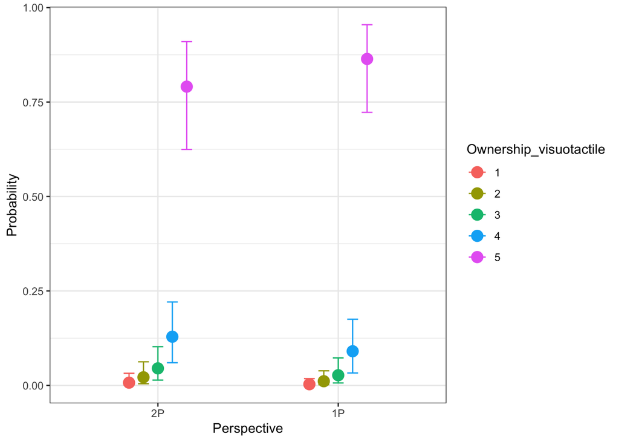

```r
plot(conditional_effects(fit_brms, "Perspective", categorical = TRUE), theme = theme_bw())
```

The error bars represent 95% credible intervals. The plot allows to visually verify that there are no clear differences in participants’ ratings between the two conditions.